# final_project

Revanth

2024-04-29

```r
# Load the required libraries
library(ggplot2)
library(dplyr)
library(factoextra)
library(psych)
```

## Data Collection

### Titanic dataset is a universally available dataset, that is used of many DS and ML use cases. It contains passengers information on the ship Titanic

```r
# Load the Titanic dataset
titanic <- read.csv('C:/Users/Admin/Desktop/MVA/titanic.csv.csv')

str(titanic)
```

```
## 'data.frame':    891 obs. of  12 variables:
##  $ PassengerId: int  1 2 3 4 5 6 7 8 9 10 ...
##  $ Survived   : int  0 1 1 1 0 0 0 0 1 1 ...
##  $ Pclass     : int  3 1 3 1 3 3 1 3 3 2 ...
##  $ Name       : chr  "Braund, Mr. Owen Harris" "Cumings, Mrs. John Bradley (Florence Briggs Thayer)" "Heikkinen, Miss. Laina" "Futrelle, Mrs. Jacques Heath (Lily May Peel)" ...
##  $ Sex        : chr  "male" "female" "female" "female" ...
##  $ Age        : num  22 38 26 35 35 NA 54 2 27 14 ...
##  $ SibSp      : int  1 1 0 1 0 0 0 3 0 1 ...
##  $ Parch      : int  0 0 0 0 0 0 0 1 2 0 ...
##  $ Ticket     : chr  "A/5 21171" "PC 17599" "STON/O2. 3101282" "113803" ...
##  $ Fare       : num  7.25 71.28 7.92 53.1 8.05 ...
##  $ Cabin      : chr  "" "C85" "" "C123" ...
##  $ Embarked   : chr  "S" "C" "S" "S" ...
```

```r
summary(titanic)
```

```
##   PassengerId       Survived          Pclass          Name
##  Min.   :  1.0   Min.   :0.0000   Min.   :1.000   Length:891
##  1st Qu.:223.5   1st Qu.:0.0000   1st Qu.:2.000   Class :character
##  Median :446.0   Median :0.0000   Median :3.000   Mode  :character
##  Mean   :446.0   Mean   :0.3838   Mean   :2.309
##  3rd Qu.:668.5   3rd Qu.:1.0000   3rd Qu.:3.000
##  Max.   :891.0   Max.   :1.0000   Max.   :3.000
##
##      Sex                 Age            SibSp           Parch
##  Length:891         Min.   : 0.42   Min.   :0.000   Min.   :0.0000
##  Class :character   1st Qu.:20.12   1st Qu.:0.000   1st Qu.:0.0000
##  Mode  :character   Median :28.00   Median :0.000   Median :0.0000
##                     Mean   :29.70   Mean   :0.523   Mean   :0.3816
##                     3rd Qu.:38.00   3rd Qu.:1.000   3rd Qu.:0.0000
##                     Max.   :80.00   Max.   :8.000   Max.   :6.0000
##                     NA's   :177
##     Ticket               Fare           Cabin             Embarked
##  Length:891         Min.   :  0.00   Length:891         Length:891
##  Class :character   1st Qu.:  7.91   Class :character   Class :character
##  Mode  :character   Median : 14.45   Mode  :character   Mode  :character
##                     Mean   : 32.20
##                     3rd Qu.: 31.00
##                     Max.   :512.33
##
```

### We do the summary analysis to understand the variables and distributions

## Question

### How does the survival rate differ between males and females across different age groups?

## Hypothesis

### Understanding how survival rates vary between males and females across different age groups is important because it provides insights into the factors that influenced survival outcomes on the titanic

### By Analyzing the interplay between gender and age, we can identify potential patterns or disparities in survival chances. This info can help us understand the social and cultural context of the time and shed light on the evacuation procedures and priorities during disaster

```r
# Checking for missing values
sapply(titanic, function(x) sum(is.na(x)))
```

```
## PassengerId    Survived      Pclass        Name         Sex         Age
##           0           0           0           0           0         177
##       SibSp       Parch      Ticket        Fare       Cabin    Embarked
##           0           0           0           0           0           0
```

### Here, I converted Survived, Pclass, Sex, Embarked into the factors.

### For age and fare, if there is null values, added mean of the column.

```r
# Data preprocessing
titanic$Survived <- as.factor(titanic$Survived)
titanic$Pclass <- as.factor(titanic$Pclass)
titanic$Sex <- as.factor(titanic$Sex)
titanic$Embarked <- as.factor(titanic$Embarked)
titanic$Age <- ifelse(is.na(titanic$Age), mean(titanic$Age, na.rm = TRUE), titanic$Age)
titanic$Fare <- ifelse(is.na(titanic$Fare), mean(titanic$Fare, na.rm = TRUE), titanic$Fare)
```

```r
# Descriptive summary statistics
summary(titanic)
```

```
##   PassengerId    Survived Pclass      Name               Sex
##  Min.   :  1.0   0:549    1:216   Length:891         female:314
##  1st Qu.:223.5   1:342    2:184   Class :character   male  :577
##  Median :446.0            3:491   Mode  :character
##  Mean   :446.0
##  3rd Qu.:668.5
##  Max.   :891.0
##       Age            SibSp           Parch           Ticket
##  Min.   : 0.42   Min.   :0.000   Min.   :0.0000   Length:891
##  1st Qu.:22.00   1st Qu.:0.000   1st Qu.:0.0000   Class :character
##  Median :29.70   Median :0.000   Median :0.0000   Mode  :character
##  Mean   :29.70   Mean   :0.523   Mean   :0.3816
##  3rd Qu.:35.00   3rd Qu.:1.000   3rd Qu.:0.0000
##  Max.   :80.00   Max.   :8.000   Max.   :6.0000
##       Fare           Cabin           Embarked
##  Min.   :  0.00   Length:891          :  2
##  1st Qu.:  7.91   Class :character   C:168
##  Median : 14.45   Mode  :character   Q: 77
##  Mean   : 32.20                      S:644
##  3rd Qu.: 31.00
##  Max.   :512.33
```

## EDA

### Now once the data is ready, we can perform EDA to get the idea(visual) about the data, distribution of data, and also relation between variables.

```r
## EDA
# converting the numeric survive indicator to factor/categorical
titanic$Survived=ifelse(titanic$Survived==1,'Yes','No')
titanic$Survived=as.factor(titanic$Survived)

head(titanic)
```

```
##   PassengerId Survived Pclass
## 1           1       No      3
## 2           2      Yes      1
## 3           3      Yes      3
## 4           4      Yes      1
## 5           5       No      3
## 6           6       No      3
##                                                  Name    Sex      Age SibSp
## 1                             Braund, Mr. Owen Harris   male 22.00000     1
## 2 Cumings, Mrs. John Bradley (Florence Briggs Thayer) female 38.00000     1
## 3                              Heikkinen, Miss. Laina female 26.00000     0
## 4        Futrelle, Mrs. Jacques Heath (Lily May Peel) female 35.00000     1
## 5                            Allen, Mr. William Henry   male 35.00000     0
## 6                                    Moran, Mr. James   male 29.69912     0
##   Parch           Ticket    Fare Cabin Embarked
## 1     0        A/5 21171  7.2500              S
## 2     0         PC 17599 71.2833   C85        C
## 3     0 STON/O2. 3101282  7.9250              S
## 4     0           113803 53.1000  C123        S
## 5     0           373450  8.0500              S
## 6     0           330877  8.4583              Q
```

```r
# Converting categorical columns from int to factors
titanic$Pclass=as.factor(titanic$Pclass)
titanic$SibSp=as.factor(titanic$SibSp)
titanic$Parch=as.factor(titanic$Parch)

head(titanic)
```

```
##   PassengerId Survived Pclass
## 1           1       No      3
## 2           2      Yes      1
## 3           3      Yes      3
## 4           4      Yes      1
## 5           5       No      3
## 6           6       No      3
##                                                  Name    Sex      Age SibSp
## 1                             Braund, Mr. Owen Harris   male 22.00000     1
## 2 Cumings, Mrs. John Bradley (Florence Briggs Thayer) female 38.00000     1
## 3                              Heikkinen, Miss. Laina female 26.00000     0
## 4        Futrelle, Mrs. Jacques Heath (Lily May Peel) female 35.00000     1
## 5                            Allen, Mr. William Henry   male 35.00000     0
## 6                                    Moran, Mr. James   male 29.69912     0
##   Parch           Ticket    Fare Cabin Embarked
## 1     0        A/5 21171  7.2500              S
## 2     0         PC 17599 71.2833   C85        C
## 3     0 STON/O2. 3101282  7.9250              S
## 4     0           113803 53.1000  C123        S
## 5     0           373450  8.0500              S
## 6     0           330877  8.4583              Q
```

```r
sum(is.na(titanic$Age))
```

```
## [1] 0
```

```r
titanic$Age[is.na(titanic$Age)] <- round(median(titanic$Age,
                                                na.rm = TRUE))

sum(is.na(titanic$Age))
```

```
## [1] 0
```

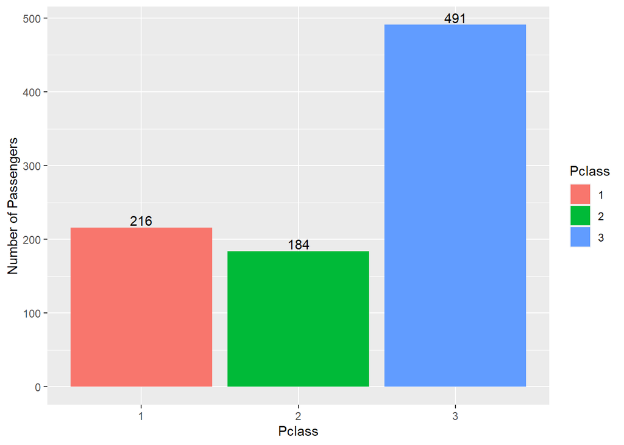

```r
#Univariate Analysis

#Question
#How any passengers are travelling in each class?

ggplot(data=titanic, aes(x=Pclass, fill = Pclass)) +
  geom_bar(position = "dodge") +
  geom_text(stat='count', aes(label=..count..), position = position_dodge(0.9),vjust=-0.2) +
  ylab("Number of Passengers")
```

### First, used bar plot to see the number of passengers in each class

### We can see most of the passengers are from class 3 (cheapest of all)

### Suprisingly there are more passengers in Class-1, than compared to Class-2

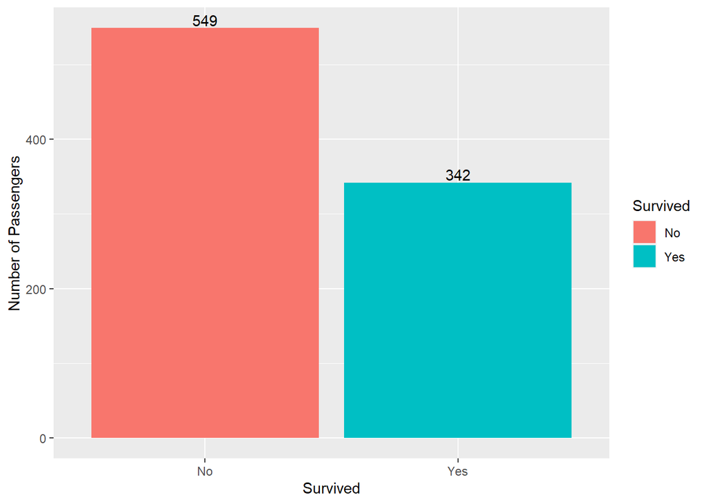

```r
# Question
# How many were survived?

ggplot(data=titanic, aes(x=Survived, fill = Survived)) +
  geom_bar(position = "dodge") +
  geom_text(stat='count', aes(label=..count..), position = position_dodge(0.9),vjust=-0.2) +
  ylab("Number of Passengers")
```

### Next, we can plot a chart based on how many were survived.

### Here we can see there are 342 that are survived, and 549 passengers who lost their lives

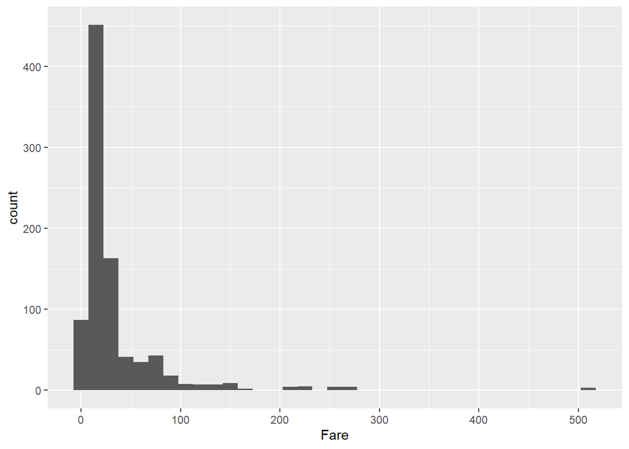

```r
# How is the price ranged?
ggplot(data=titanic, aes(x=Fare,)) +
  geom_histogram(binwidth = 15) +
  xlab("Fare")
```

### Next, price distribution using histogram.

### The tickets fare are consistent with the ticket class for sure, as the highest number of ticket purchased is the cheapest one offered to board the Titanic.

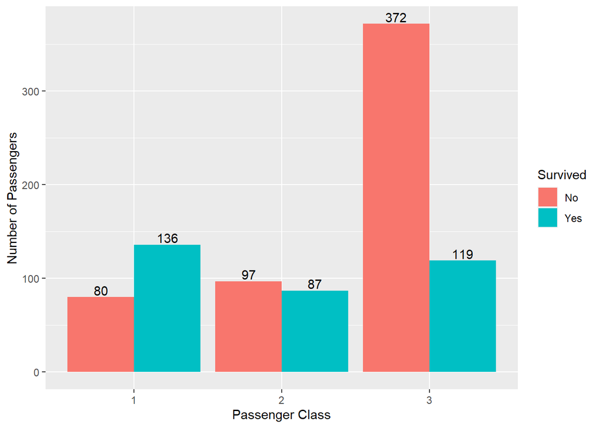

```r
# Which class passengers has high survival chance
ggplot(titanic, aes(x=Pclass,fill=Survived))+ geom_bar(position = "dodge") + geom_text(stat='count',aes(label=..count..),position = position_dodge(0.9),vjust=-0.2) +
  ylab("Number of Passengers") + xlab("Passenger Class")
```

### Next, important thing which class passengers has high survival chances?

### From the chart we can conclude that people who paid more ie, Class-1 had much better chance of survival as compared to others.

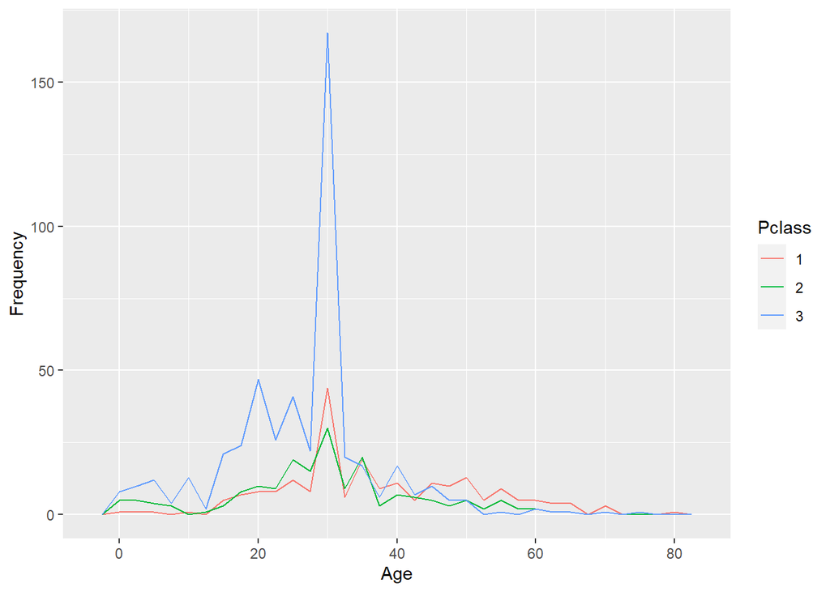

```r
# what ticket was selected by what age of passengers?
ggplot(titanic) + geom_freqpoly(mapping = aes(x = Age, color = Pclass), binwidth = 2.5) +
  ylab("Frequency")
```

### HEre, we can see that most of the passengers irrespective of ticket class are almost of similar age (approx 30)

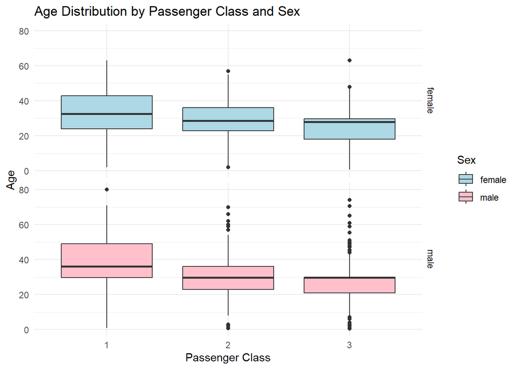

```r
# Age Distribution by passenger class and sex
ggplot(titanic, aes(x=factor(Pclass), y=Age, fill=Sex)) +
  geom_boxplot() +
  facet_grid(Sex ~ .) +
  scale_fill_manual(values=c("lightblue", "pink"), name="Sex") +
  labs(title="Age Distribution by Passenger Class and Sex",
       x="Passenger Class",
       y="Age") +
  theme_minimal()
```

## This faceted boxplot also shows almost similar that most of the passengers

## were from age 20-40 including all the ticket classes.

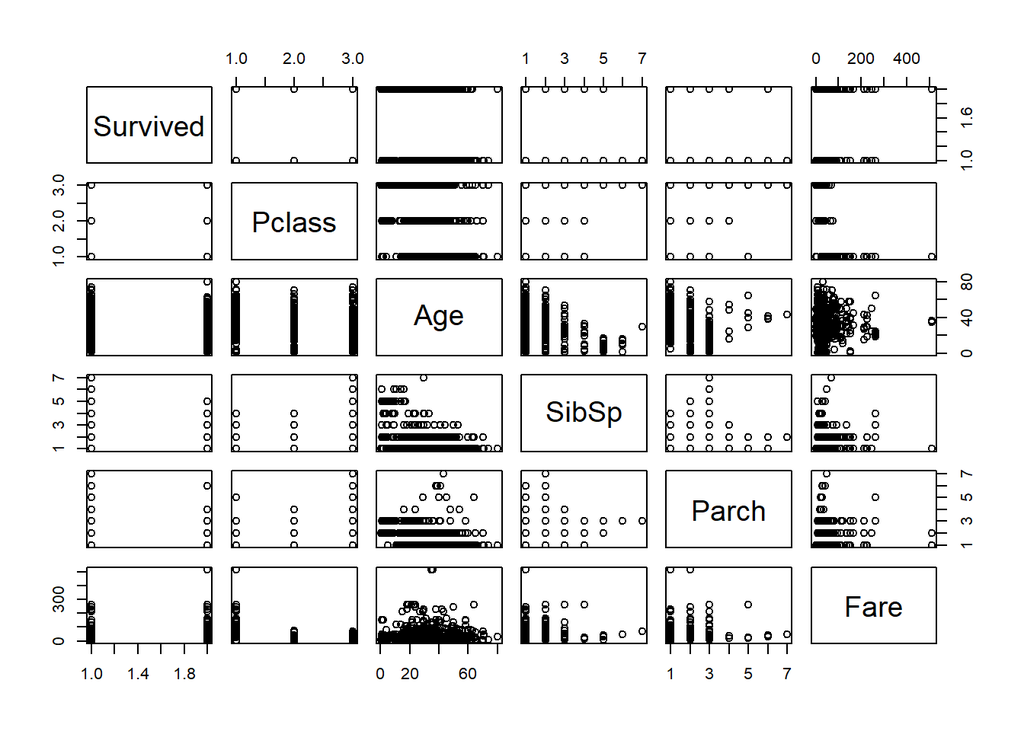

```r
# Scatterplot matrix for the numerical columns in the data
numeric_vars <- titanic[, c("Survived", "Pclass", "Age", "SibSp", "Parch", "Fare")]
pairs(numeric_vars)
```

## General Descriptive Data analysis and visualization

```r
# Select relevant variables for analysis
titanic <- read.csv('C:/Users/Admin/Desktop/MVA/titanic.csv.csv')
selected_vars <- c("Survived", "Pclass", "Sex", "Age", "SibSp", "Parch", "Fare")
titanic_subset <- titanic[, selected_vars]
```

```r
# Handle missing values
titanic_subset$Age <- ifelse(is.na(titanic_subset$Age), mean(titanic_subset$Age, na.rm = TRUE), titanic_subset$Age)
titanic_subset$Fare <- ifelse(is.na(titanic_subset$Fare), mean(titanic_subset$Fare, na.rm = TRUE), titanic_subset$Fare)
```

# Models

## PCA

### PCA helps us identify the pricipal components that explain the most variance in the data. The scree plot shows the eigen values associated with each principal components helping us determine the optimal number of components to retain.

### The biplot visualizes the relationships between variables and observations

```r
# Convert categorical variables to numeric
titanic_subset$Sex <- as.numeric(factor(titanic_subset$Sex))
titanic_subset$Survived <- as.numeric(titanic_subset$Survived)
```

```r
# Normalize the data
titanic_scaled <- scale(titanic_subset)
```

## PCA can help us identify key variables that contribute to the variation in survival rates between males and females across age groups

```r
# Perform PCA
pca_result <- prcomp(titanic_scaled)

# Print the summary of PCA
summary(pca_result)
```

```
## Importance of components:
##                           PC1    PC2    PC3    PC4     PC5     PC6     PC7
## Standard deviation     1.4498 1.2995 1.0778 0.8532 0.74966 0.65056 0.57860
## Proportion of Variance 0.3003 0.2412 0.1659 0.1040 0.08028 0.06046 0.04783
## Cumulative Proportion  0.3003 0.5415 0.7075 0.8114 0.89171 0.95217 1.00000
```

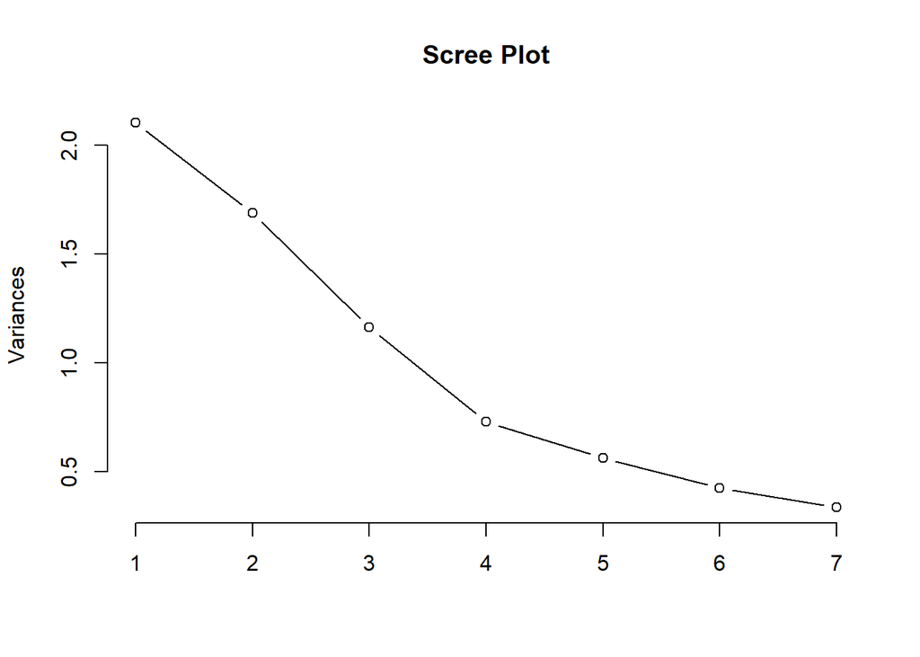

```r
# Scree plot to determine the number of principal components
screeplot(pca_result, type = "lines", main = "Scree Plot")
```

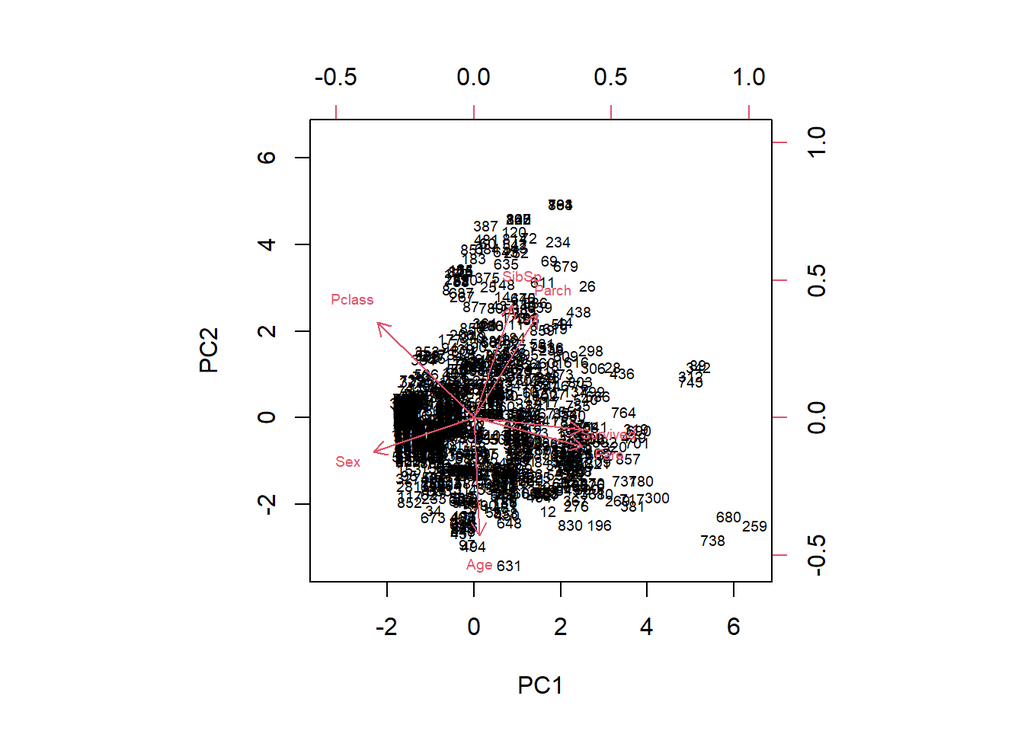

```r
# Biplot to visualize the relationships between variables and observations
biplot(pca_result, scale = 0, cex = 0.6)
```

## Factor Analysis

### This helps in indetifying latent factors that explain the correlarions among variables

### The summary of factor analysis provides information about the factor loadings which indicate the strengths and directions of the relationship between the variables and extracted factors.

```r
# Perform Factor Analysis
factor_result <- factanal(titanic_scaled, factors = 3, rotation = "varimax")

# Print the summary of Factor Analysis
print(factor_result)
```

```
##
## Call:
## factanal(x = titanic_scaled, factors = 3, rotation = "varimax")
##
## Uniquenesses:
## Survived   Pclass      Sex      Age    SibSp    Parch     Fare
##    0.005    0.048    0.641    0.776    0.602    0.541    0.570
##
## Loadings:
##          Factor1 Factor2 Factor3
## Survived  0.161   0.982
## Pclass   -0.952  -0.181   0.115
## Sex              -0.558  -0.212
## Age       0.340  -0.146  -0.295
## SibSp                     0.631
## Parch             0.121   0.666
## Fare      0.573   0.185   0.258
##
##                Factor1 Factor2 Factor3
## SS loadings      1.381   1.379   1.057
## Proportion Var   0.197   0.197   0.151
## Cumulative Var   0.197   0.394   0.545
##
## Test of the hypothesis that 3 factors are sufficient.
## The chi square statistic is 11.17 on 3 degrees of freedom.
## The p-value is 0.0108
```

## For our question, this alone in not the appropriate method, but this analysis can further complement the previous analysis to better understand the relationship betwwen variables.

## It would typically be used if we wanted to reduce a larger set of variables into fewer dimensions(factors)

## It wouldn’t typically be applied to analyze direct differences in survival rates.

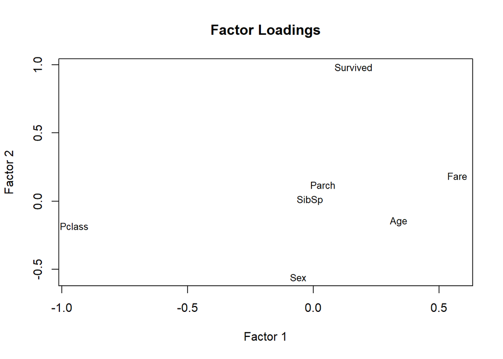

```r
# Plot the factor loadings
load <- factor_result$loadings[, 1:3]
plot(load, type = "n", main = "Factor Loadings", xlab = "Factor 1", ylab = "Factor 2")
text(load, labels = rownames(load), cex = 0.8)
```

## Clustering

### Clustering is an interesting approach to explore patterns of survival among passengers on titanic, grouping individuals based on similarities across multiple variables inclusing Age and Sex to see how these clusters relate to survival rates,

```r
library(tidyverse)
library(cluster)
# Load data
titanic_data <- titanic::titanic_train
```

```r
# Preprocess the data
titanic_data <- titanic_data %>%
  filter(!is.na(Age), !is.na(Fare)) %>%
  mutate(Sex = as.numeric(factor(Sex, levels = c("male", "female"))))
```

```r
# Scale the data
titanic_scaled <- scale(titanic_data[, c("Age", "Sex", "Fare")])
```

```r
set.seed(123)  # For reproducibility
kmeans_result <- kmeans(titanic_scaled, centers = 4, nstart = 25)
```

```r
# Add cluster assignments back to the data
titanic_data$Cluster <- kmeans_result$cluster
```

### The clustering analysis can reveal the pattern, such as whether younger, wealthiness or female passengers as clusters and had higher survival rate.

```r
# Calculate survival rates by cluster
survival_by_cluster <- titanic_data %>%
  group_by(Cluster) %>%
  summarise(Count = n(),
            Survivors = sum(Survived, na.rm = TRUE),
            SurvivalRate = mean(Survived, na.rm = TRUE))
# Print the survival rates by cluster
print(survival_by_cluster)
```

```
## # A tibble: 4 × 4
##   Cluster Count Survivors SurvivalRate
##     <int> <int>     <int>        <dbl>
## 1       1   230       169        0.735
## 2       2   137        29        0.212
## 3       3   316        68        0.215
## 4       4    31        24        0.774
```

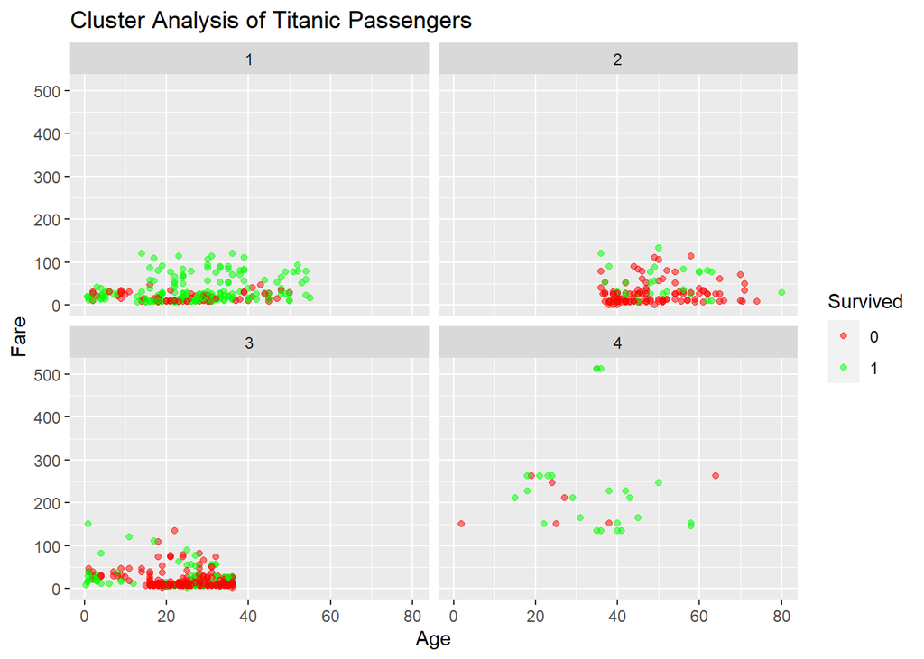

```r
ggplot(titanic_data, aes(x = Age, y = Fare, color = factor(Survived))) +
  geom_point(alpha = 0.5) +
  facet_wrap(~Cluster) +
  scale_color_manual(values = c("red", "green")) +
  labs(title = "Cluster Analysis of Titanic Passengers",
       x = "Age",
       y = "Fare",
       color = "Survived")
```

### This can further enhance the analysis, It provides a comprehensive view by grouping similar passengers together and examining their outcomes as collectives.

## Logistic Regression

### It is a type of regression analysis used for predicting the outcome of categorical dependent variable based on one or more predictor variables.

```r
library(titanic)
```

```r
library(dplyr)
library(ggplot2)
library(caret)
# Load the data
data(titanic_train)
titanic_data <- titanic_train
```

```r
# Convert 'Sex' to a factor as it is a categorical variable
titanic_data$Sex <- factor(titanic_data$Sex, levels = c("male", "female"))
```

## Here, we are using glm() function in R to perform logistic regression, specifying ‘binomial’ for binomial logistic regression.

## We are performing below analysis using single predictor

```r
# Simple logistic regression with Sex as a predictor
model_sex <- glm(Survived ~ Sex, family = binomial(), data = titanic_data)
summary(model_sex)
```

```
##
## Call:
## glm(formula = Survived ~ Sex, family = binomial(), data = titanic_data)
##
## Coefficients:
##             Estimate Std. Error z value Pr(>|z|)
## (Intercept)  -1.4571     0.1064  -13.70   <2e-16 ***
## Sexfemale     2.5137     0.1672   15.04   <2e-16 ***
## ---
## Signif. codes:  0 '***' 0.001 '**' 0.01 '*' 0.05 '.' 0.1 ' ' 1
##
## (Dispersion parameter for binomial family taken to be 1)
##
##     Null deviance: 1186.7  on 890  degrees of freedom
## Residual deviance:  917.8  on 889  degrees of freedom
## AIC: 921.8
##
## Number of Fisher Scoring iterations: 4
```

```r
# Add predicted probabilities to the data frame
titanic_data$predicted <- predict(model_sex, type = "response")
```

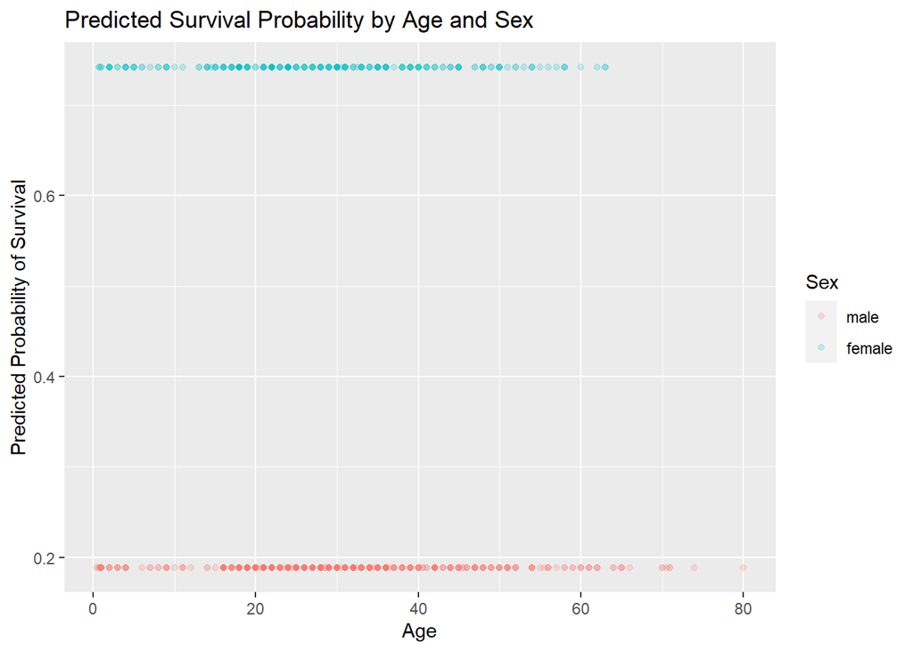

```r
# Plotting
ggplot(titanic_data, aes(x = Age, y = predicted, color = Sex)) +
  geom_point(alpha = 0.2) +
  labs(title = "Predicted Survival Probability by Age and Sex",
       x = "Age",
       y = "Predicted Probability of Survival")
```

## Finding Accuracy

```r
# Predict probabilities
probabilities <- predict(model_sex, type = "response")

# Convert probabilities to binary predictions
predictions <- ifelse(probabilities > 0.5, 1, 0)

# Actual survival data
actual <- titanic_data$Survived

# Calculate accuracy
accuracy <- mean(predictions == actual)
print(paste("Accuracy:", accuracy))
```

```
## [1] "Accuracy: 0.78675645342312"
```

### we can see that the model has accuracy of around 79%, which is still not the best but compared to others it is performing well.

```r
# Create a confusion matrix
conf_matrix <- confusionMatrix(as.factor(predictions), as.factor(actual))

# Print the confusion matrix along with other stats
print(conf_matrix)
```

```
## Confusion Matrix and Statistics
##
##           Reference
## Prediction   0   1
##          0 468 109
##          1  81 233
##
##                Accuracy : 0.7868
##                  95% CI : (0.7584, 0.8132)
##     No Information Rate : 0.6162
##     P-Value [Acc > NIR] : < 2e-16
##
##                   Kappa : 0.5421
##
##  Mcnemar's Test P-Value : 0.05014
##
##             Sensitivity : 0.8525
##             Specificity : 0.6813
##          Pos Pred Value : 0.8111
##          Neg Pred Value : 0.7420
##              Prevalence : 0.6162
##          Detection Rate : 0.5253
##    Detection Prevalence : 0.6476
##       Balanced Accuracy : 0.7669
##
##        'Positive' Class : 0
##
```

## Multiple Regression

```r
# Handling missing values in 'Age'
titanic_data$Age <- ifelse(is.na(titanic_data$Age), median(titanic_data$Age, na.rm = TRUE), titanic_data$Age)
titanic_data$Sex <- factor(titanic_data$Sex)
titanic_data$Pclass <- as.factor(titanic_data$Pclass)
```

```r
# Multiple logistic regression with Sex and Age as predictors
model<- glm(Survived ~ Sex + Age + Pclass, family = binomial(), data = titanic_data)
summary(model)
```

```
##
## Call:
## glm(formula = Survived ~ Sex + Age + Pclass, family = binomial(),
##     data = titanic_data)
##
## Coefficients:
##              Estimate Std. Error z value Pr(>|z|)
## (Intercept)  0.919304   0.326511   2.816  0.00487 **
## Sexfemale    2.611494   0.186623  13.993  < 2e-16 ***
## Age         -0.033177   0.007387  -4.491 7.08e-06 ***
## Pclass2     -1.115391   0.257326  -4.335 1.46e-05 ***
## Pclass3     -2.334168   0.241503  -9.665  < 2e-16 ***
## ---
## Signif. codes:  0 '***' 0.001 '**' 0.01 '*' 0.05 '.' 0.1 ' ' 1
##
## (Dispersion parameter for binomial family taken to be 1)
##
##     Null deviance: 1186.66  on 890  degrees of freedom
## Residual deviance:  805.53  on 886  degrees of freedom
## AIC: 815.53
##
## Number of Fisher Scoring iterations: 5
```

```r
# Predict probabilities
probabilities <- predict(model, type = "response")

# Convert probabilities to binary predictions
predictions <- ifelse(probabilities > 0.5, 1, 0)

# Actual survival data
actual <- titanic_data$Survived

# Calculate accuracy
accuracy <- mean(predictions == actual)
print(paste("Accuracy:", accuracy))
```

```
## [1] "Accuracy: 0.801346801346801"
```

### This has the accuracy of aroung 80%

### Building Confusion Matrix

```r
# Create a confusion matrix
conf_matrix <- confusionMatrix(as.factor(predictions), as.factor(actual))

# Display the confusion matrix and other statistics
print(conf_matrix)
```

```
## Confusion Matrix and Statistics
##
##           Reference
## Prediction   0   1
##          0 472 100
##          1  77 242
##
##                Accuracy : 0.8013
##                  95% CI : (0.7736, 0.8271)
##     No Information Rate : 0.6162
##     P-Value [Acc > NIR] : <2e-16
##
##                   Kappa : 0.5746
##
##  Mcnemar's Test P-Value : 0.0982
##
##             Sensitivity : 0.8597
##             Specificity : 0.7076
##          Pos Pred Value : 0.8252
##          Neg Pred Value : 0.7586
##              Prevalence : 0.6162
##          Detection Rate : 0.5297
##    Detection Prevalence : 0.6420
##       Balanced Accuracy : 0.7837
##
##        'Positive' Class : 0
##
```

## Key Knowledge

### 2. PassengerClass and Fare

#### Passengers in higher Pclass(1 and 2) had better chances of survival chances compared to lower classes.

#### Higher fare associated with increased likelihood.

### This suggests that socio-economic status and ticket fare influenced survival rates.

### Logistic regression model revealed that being female increaed the odds of survical while other age decreased the odds.

# The major factors that played key roles in answering the above question are

## 1. Gender Impact

## 2. Socio Economic factor

## 3. Age Influence